# Homework 8

Katarzyna Kańska

26.11.2015

## Goals

For the Drosophila study check what will happen with coefficients if:

1. all variables are included into a model and standard MLE estimates are calculated,
2. ridge regression is applied,
3. lasso regression is applied.

For points b) and c) present how model coefficient behaves as a function of penalty/parameter.

## Solution

Firstly, we load the data.

```r
library(PBImisc)
attach(Drosophila)

df <- bs[,1:42]
```

### Standard MLE estimates for full model

Under standard assumptions of linear model the OLS estimator is BLUE (Best Linear Unbiased Estimator). Normal distribution of random noise provides that this estimator is also MLE (Maximum Likelihood Estimator).

```r
modelMLE <- lm(pc1 ~ . , data=df)
summary(modelMLE)
```

```
##
## Call:
## lm(formula = pc1 ~ ., data = df)
##
## Residuals:
##        Min         1Q     Median         3Q        Max
## -0.0072665 -0.0014057  0.0001699  0.0014915  0.0055572
##
## Coefficients:
##               Estimate Std. Error t value Pr(>|t|)
## (Intercept)  3.235e-02  3.823e-04  84.606  < 2e-16 ***
## ewg          3.511e-04  3.204e-04   1.096 0.273845
## w           -1.538e-03  3.493e-04  -4.403 1.41e-05 ***
## rp          -1.575e-04  2.547e-04  -0.618 0.536865
## v           -1.347e-03  2.400e-04  -5.613 3.98e-08 ***
## sd           5.128e-04  2.097e-04   2.446 0.014938 *
## run         -1.574e-04  1.852e-04  -0.850 0.395895
## gl          -1.015e-03  5.081e-04  -1.997 0.046529 *
## pgk         -2.708e-04  5.803e-04  -0.467 0.641057
## cg          -1.554e-03  7.438e-04  -2.089 0.037399 *
## gpdh        -1.521e-03  8.210e-04  -1.852 0.064837 .
## ninaC       -1.366e-03  7.092e-04  -1.926 0.054905 .
## glt          2.981e-04  5.744e-04   0.519 0.604116
## mhc         -2.329e-03  6.165e-04  -3.777 0.000186 ***
## ddc          5.843e-04  7.695e-04   0.759 0.448202
## duc         -8.814e-04  5.273e-04  -1.672 0.095463 .
## sli         -7.976e-04  3.040e-04  -2.624 0.009063 **
## egfr        -9.263e-05  6.282e-04  -0.147 0.882867
## twi         -2.268e-05  7.663e-04  -0.030 0.976409
## zip         -1.033e-03  5.156e-04  -2.004 0.045768 *
## lsp         -3.941e-04  5.732e-04  -0.688 0.492140
## ve          -1.365e-03  6.848e-04  -1.993 0.047048 *
## acr          2.711e-04  6.661e-04   0.407 0.684288
## dbi         -2.581e-03  6.759e-04  -3.819 0.000158 ***
## h           -4.358e-04  4.766e-04  -0.914 0.361072
## fz          -4.372e-03  6.595e-04  -6.628 1.24e-10 ***
## eip          1.256e-03  7.741e-04   1.623 0.105528
## tra          1.314e-05  6.132e-04   0.021 0.982911
## rdg         -1.025e-03  6.979e-04  -1.469 0.142811
## ht          -2.019e-03  7.806e-04  -2.587 0.010082 *
## ant          1.009e-03  7.691e-04   1.313 0.190182
## ninaE       -1.895e-03  6.318e-04  -3.000 0.002890 **
## fas         -7.491e-04  5.215e-04  -1.436 0.151807
## mst         -1.014e-03  5.100e-04  -1.988 0.047624 *
## odh          4.493e-04  7.341e-04   0.612 0.540895
## tub         -1.709e-03  7.278e-04  -2.348 0.019416 *
## hb          -9.094e-04  5.445e-04  -1.670 0.095783 .
## rox         -1.562e-03  4.930e-04  -3.169 0.001660 **
## ald         -7.848e-04  6.830e-04  -1.149 0.251330
## mlc         -8.374e-04  6.801e-04  -1.231 0.219030
## jan         -1.682e-03  7.914e-04  -2.125 0.034258 *
## efi         -6.421e-04  7.207e-04  -0.891 0.373579
## ---
## Signif. codes:  0 '***' 0.001 '**' 0.01 '*' 0.05 '.' 0.1 ' ' 1
##
## Residual standard error: 0.002316 on 360 degrees of freedom
## Multiple R-squared:  0.9093, Adjusted R-squared:  0.899
## F-statistic: 88.04 on 41 and 360 DF,  p-value: < 2.2e-16
```

```r
library(car)
vif(modelMLE)
```

```
##       ewg         w        rp         v        sd       run        gl
##  7.690664  9.137029  4.800058  4.202430  2.917888  2.141868  4.794329
##       pgk        cg      gpdh     ninaC       glt       mhc       ddc
##  6.284281 10.253837 12.402848  9.290877  6.062582  6.698641 10.295207
##       duc       sli      egfr       twi       zip       lsp        ve
##  4.900250  1.695382  7.369367 10.980767  4.962627  6.144002  8.744777
##       acr       dbi         h        fz       eip       tra       rdg
##  8.272664  8.539726  4.253744  8.014706 11.055961  6.976073  9.046203
##        ht       ant     ninaE       fas       mst       odh       tub
## 11.227116 10.836373  7.225617  4.983311  4.810534 10.007537  9.854711
##        hb       rox       ald       mlc       jan       efi
##  5.529557  4.549265  8.740273  8.656464 11.685838  9.664005
```

The full model suffers from high colinearity. Therefore we need to select some subset of explanatory variables.

### Ridge regression

To stabilize estimates we perform the ridge regression. To have a full image of the situation, we are interested in dependence of coefficients as a function of parameter ‘lambda’.

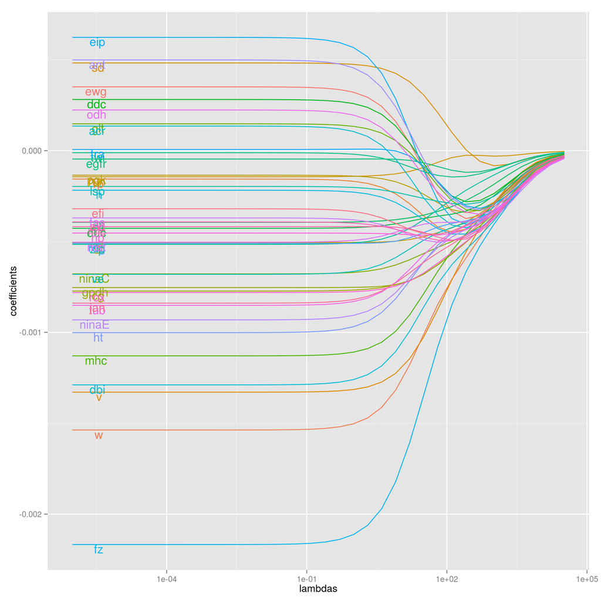

```r
lambdas <- 2^((-20):15)
coefsR <- sapply(lambdas, function(lambda) {
  lm.ridge(pc1 ~ . , data=df, lambda=lambda)$coef
})
RIDGEcoeffs <- data.frame(t(coefsR), lambdas)

library("tidyr")

RIDGEcoeffs2 <- gather(RIDGEcoeffs, variable, coefficient, -lambdas)

library("ggplot2")
ggplot(RIDGEcoeffs2, aes(x=lambdas, y=coefficient, color=variable)) +
  geom_line() + ylab("coefficients") +
  scale_x_log10() +
  theme(legend.position = "none") +
  geom_text(data = RIDGEcoeffs2[RIDGEcoeffs2$lambdas==2^(-18),], aes(label = variable), hjust = 0.7, vjust = 1, size=5)
```

For such number of variables it is hard to describe the behaviour of each coeeficient. We can only have some general observations like the strange behaviour of coefficients that almost all converge to very similar value. Moreover, in some cases this causes a change of sign.

In order to choose the best model we use GCV criterion (Generalized Cross-Validation) which is often recommended for ridge regression.

```r
library("broom")    # package for converting statistical analysis objects into tidy data frames
fit <- lm.ridge(pc1 ~ . , data=df, lambda=lambdas)
td <- tidy(fit)
head(td)
```

```
##         lambda          GCV term     estimate
## 1 9.536743e-07 1.481583e-08  ewg 0.0003510493
## 2 1.907349e-06 1.481583e-08  ewg 0.0003510493
## 3 3.814697e-06 1.481583e-08  ewg 0.0003510492
## 4 7.629395e-06 1.481583e-08  ewg 0.0003510491
## 5 1.525879e-05 1.481583e-08  ewg 0.0003510489
## 6 3.051758e-05 1.481583e-08  ewg 0.0003510484
```

```r
g <- glance(fit)
g
```

```
##       kHKB     kLW lambdaGCV
## 1 9.856313 4.34339        16
```

```r
# lambdaGCV is the one we are looking for
```

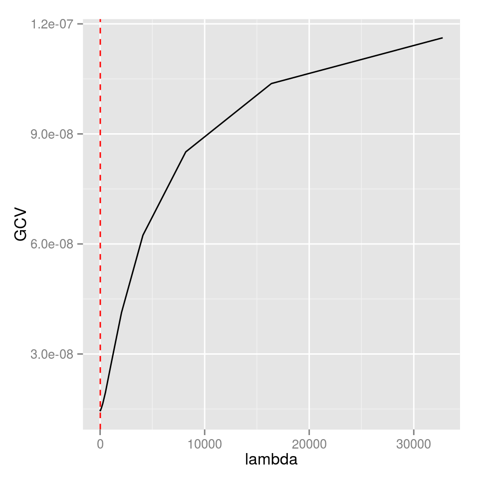

```r
ggplot(td, aes(x=lambda, y=GCV)) + geom_line() +
    geom_vline(xintercept = g$lambdaGCV, col = "red", lty = 2)
```

```r
modelRIDGE <- lm.ridge(pc1 ~ . , data=df, lambda=g$lambdaGCV)
```

We conclude the results in the Comparison section.

### Lasso regression

Now we perform lasso regresion.

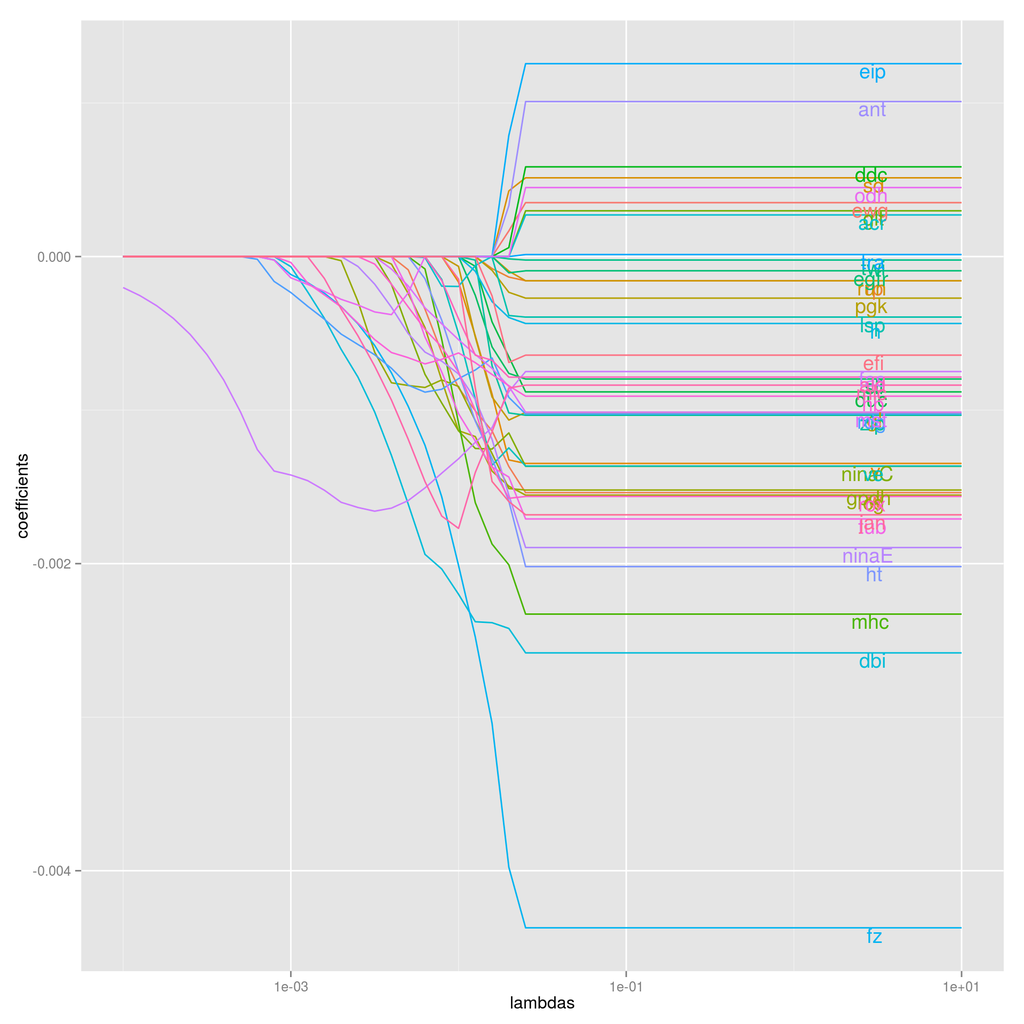

```r
library("lasso2")

lambdas <- 10^seq(-4,1,0.1)
coefsL <- sapply(lambdas, function(lambda) {
  l1ce(pc1 ~ . , data=df, bound=lambda, absolute.t=TRUE)$coef
})
LASSOcoeffs <- data.frame(t(coefsL[2:42,]), lambdas)
LASSOcoeffs2 <- gather(LASSOcoeffs, variable, coefficient, -lambdas)

ggplot(LASSOcoeffs2, aes(x=lambdas, y=coefficient, color=variable)) +
  geom_line() + ylab("coefficients") +
  scale_x_log10() +
  theme(legend.position = "none") +
  geom_text(data = LASSOcoeffs2[LASSOcoeffs2$lambdas==10^0.5,], aes(label = variable), hjust = 0.7, vjust = 1, size=5)
```

These results are easier to interprete, because coefficients do not change their sign and we are even able to distinguish at which point each coefficient (or at least a set of coefficients) approaches zero.

Again, we need a critetion to choose the proper model. Here we select the model with largest value of lambda such that error is within 1 standard error of the minimum.

```r
library("glmnet")
cvfit <- cv.glmnet(as.matrix(df[,colnames(df)!="pc1"]),df$pc1)
chosenLASSO <- coef(cvfit, s = "lambda.1se")
```

## Comparison

Now we compare the results for standard linear model with rigde and lasso regression.

```r
coeffs <- data.frame( MLE = coef(modelMLE), RIDGE = coef(modelRIDGE), LASSO = as.numeric(chosenLASSO))
coeffs
```

```
##                       MLE         RIDGE         LASSO
## (Intercept)  3.234775e-02  3.218626e-02  3.036373e-02
## ewg          3.511189e-04  4.086240e-05  0.000000e+00
## w           -1.537647e-03 -1.177995e-03 -1.137348e-03
## rp          -1.574663e-04 -2.942485e-04 -8.063674e-05
## v           -1.347338e-03 -1.160173e-03 -9.047061e-04
## sd           5.127757e-04  4.023234e-04  0.000000e+00
## run         -1.573789e-04 -1.252851e-04  0.000000e+00
## gl          -1.014901e-03 -9.832544e-04 -9.240575e-04
## pgk         -2.707906e-04 -3.995460e-04 -9.229635e-05
## cg          -1.553906e-03 -1.437276e-03 -1.398159e-03
## gpdh        -1.520561e-03 -1.446313e-03 -1.289795e-03
## ninaC       -1.365884e-03 -1.209333e-03 -1.254372e-03
## glt          2.980874e-04 -1.932878e-05  0.000000e+00
## mhc         -2.328605e-03 -1.862558e-03 -1.878984e-03
## ddc          5.842563e-04  8.637734e-05  0.000000e+00
## duc         -8.814409e-04 -8.011163e-04 -4.319024e-04
## sli         -7.975930e-04 -7.473195e-04 -5.967376e-04
## egfr        -9.262804e-05 -1.072014e-04  0.000000e+00
## twi         -2.267546e-05 -1.773806e-04  0.000000e+00
## zip         -1.033398e-03 -8.581043e-04 -7.264949e-04
## lsp         -3.941309e-04 -4.920417e-04 -2.663762e-06
## ve          -1.364616e-03 -1.084730e-03 -1.366924e-03
## acr          2.710531e-04 -2.994327e-04  0.000000e+00
## dbi         -2.581086e-03 -1.988073e-03 -2.391862e-03
## h           -4.358476e-04 -6.567978e-04 -2.892631e-04
## fz          -4.371694e-03 -3.238971e-03 -3.051421e-03
## eip          1.256202e-03  1.915928e-04  0.000000e+00
## tra          1.314375e-05 -5.851738e-05  0.000000e+00
## rdg         -1.025004e-03 -9.640947e-04 -6.727166e-04
## ht          -2.019195e-03 -1.444393e-03 -1.300710e-03
## ant          1.009427e-03  2.024849e-04  0.000000e+00
## ninaE       -1.895145e-03 -1.420890e-03 -1.203325e-03
## fas         -7.490480e-04 -9.386101e-04 -1.114086e-03
## mst         -1.013685e-03 -8.543367e-04 -7.285476e-04
## odh          4.492945e-04 -7.259893e-05  0.000000e+00
## tub         -1.708877e-03 -1.310830e-03 -1.370462e-03
## hb          -9.094134e-04 -9.263416e-04 -7.741184e-04
## rox         -1.562473e-03 -1.434409e-03 -1.375390e-03
## ald         -7.847963e-04 -9.090716e-04 -6.715540e-04
## mlc         -8.373736e-04 -8.619881e-04 -1.136431e-03
## jan         -1.681738e-03 -1.347152e-03 -1.483555e-03
## efi         -6.420986e-04 -8.695172e-04 -2.591413e-04
```

These coefficients seem to differ much, but for better comparison we look at some graphical representation of this data.

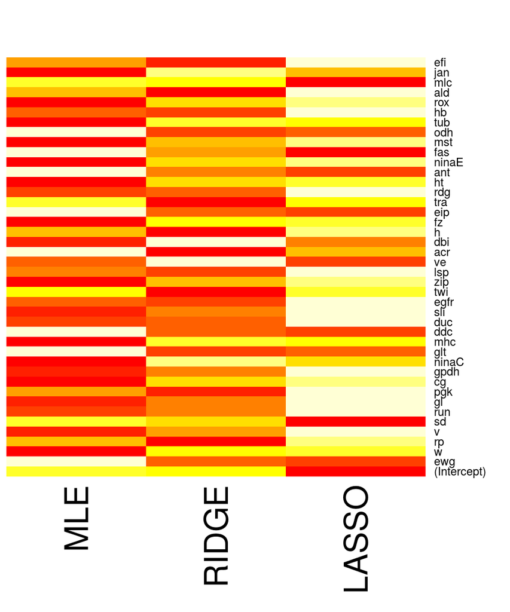

```r
heatmap(as.matrix(coeffs), Rowv=NA, Colv=NA)
```

This confirms our previous impression that coefficients derived from three different methods vary much.

Let us see how many variables had coefficient greater than $10^{-4}$ or zero.

```r
sum(as.numeric(abs(coeffs$MLE)>10^(-4)))
```

```
## [1] 39
```

```r
sum(as.numeric(abs(coeffs$RIDGE)>10^(-4)))
```

```
## [1] 37
```

```r
sum(as.numeric(coeffs$LASSO!=0))
```

```
## [1] 30
```

As we expected, lasso regression chooses the smallest number of variables.

At this point, the only conclusion I am able to come up with, is that the model selection is a very hard problem and we have to know exactly what issue we are dealing with. This time probably the results from ridge regression would fit our case as we strugle with the colinearity of predictors.